# The effect of vitamin C on tooth growth in guinea pigs

Student

August 19, 2015

## Introduction

In this assignment we’ll use **R** to explore, study, and draw conclusions about the effect of vtamin C on tooth growth in guinea pigs.

The data used is the **ToothGrowth** dataset from R’s `datasets` package, and contains observations on odontoblast length in 60 guinea pigs, each of which received one of three dosages of vitamin C (0.5, 1, and 2 mg/day) via one of two delivery methods (orange juice or ascorbic acid).

The data comes from a [1947 study by Crampton, E.W](http://jn.nutrition.org/content/33/5/491.full.pdf).

## Exploratory Data Analysis

To visually explore the sample data from each of the six groups of 10 guinea pigs, we use a boxplot. The boxplot shows quartiles and outliers (indicated by solid dots). Additionally, we’ve drawn a dashed line connecting the mean of each group.

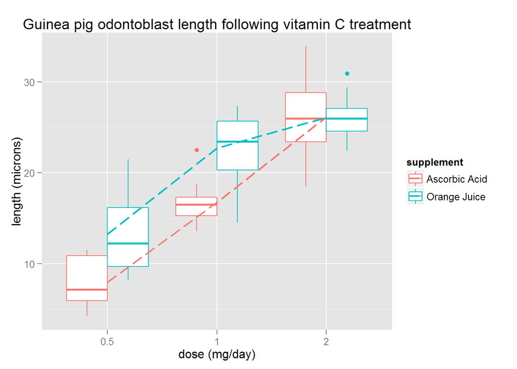

A few things are apparent about the *sample* data; odontoblast length were on average higher in groups with higher dosage, and at `0.5 mg/day` and `1.0 mg/day` dosage groups, supplement means were quite distinct. However, in order to make inferences about *population* means, we turn to hypothesis testing.

## Hypothesis testing

We will use hypothesis testing to quantitatively evaluate whether a particular statement about the unknown population means is *likely*. We begin by constructing two hypotheses, the **null hypothesis** and the **alternate hypothesis**. For two groups $X$ and $Y$ with unknown population means $\mu_X$ and $\mu_Y$ respectively, we construct:

1. **Null hypothesis H<sub>0</sub>**: $\mu_X - \mu_Y = 0$
2. **Alternate hypothesis H<sub>a</sub>**: $\mu_X - \mu_Y \ne 0$

In order to compare $X$ and $Y$, we must select a suitable two-sample test given the parameters of our experiment, and evaluate the null hypothesis using it.

## Assumptions

We make the following basic assumptions:

1. $X$ and $Y$ are i.i.d normal random variables with mean and finite variance.
2. $X$ and $Y$ are independent of each other.
3. $\bar{X}$ and $\bar{Y}$ follow a known distribution.

Because there are 60 distinct guinea pigs in the data (a point once ambiguous in the **R** documentation, but updated as of R 3.2.2), the $X$ and $Y$ populations for no two groups overlap, and we do not have a paired experiment.

For small sample sizes (in our case $10$ guinea pigs in each group) it is more robust to assume that the sample means follow a *t* distribution. For larger samples, the sample mean may instead be treated as normal, owing to the Central Limit Theorem.

## Welch’s t test

Welch’s *t* test is a two-sample statistical test evaluating whether the population means of two populations is equal or distinct. It was introduced in the lectures and will be evaluated using the `t.test` function in **R**. A brief summary of test output follows.

### Confidence interval

Welch’s *t* test assigns a confidence interval for the difference in population means $\mu_X - \mu_Y$ in terms of known or calculable sample statistics. For a chosen $(1 - \alpha) \cdot 100$% confidence level (usually 95%), it is given by:

$$\bar{X} - \bar{Y} \pm t_{\alpha/2,df} \sqrt{\frac{s^2_X}{n_X} + \frac{s^2_Y}{n_Y}}$$

where $t$ is the critical $t$ value (calculable via `qt()`) and the degrees of freedom $df$ is given by:

$$df = \frac{(\frac{s^2_X}{n_X} + \frac{s^2_Y}{n_Y})^2}{\frac{(s^2_X/n_X)^2}{n_X - 1} + \frac{(s^2_Y/n_Y)^2}{n_Y - 1}}$$

The immediate consequences of the 95% confidence interval are:

1. If the interval contains zero, then we cannot reject the **H<sub>0</sub>** with 95% confidence.
2. If the interval does not contain zero, then we reject **H<sub>0</sub>** in favor of **H<sub>a</sub>** with 95% confidence.
   1. If the interval is strictly positive, then we express confidence in $\mu_X > \mu_Y$.
   2. If the interval is strictly negative, then we express confidence in $\mu_Y > \mu_X$.

### The p value

The *p* value is the result of the statistical test which we select, and quantifies the success or failure of the null hypothesis **H<sub>0</sub>**. It is the probability that the null hypothesis version of population parameters could have yielded the observed sample statistic.

## Differences in dosage

### Orange Juice

```r
  welch.test(length ~ dose,
    data = tg[(dose == 1.0 | dose == 0.5) & (supplement == "Orange Juice")])
```

```
## 95% confidence interval:  -13.4156, -5.52437
## p value:  8.78492e-05
```

```r
  welch.test(length ~ dose,
    data = tg[(dose == 2.0 | dose == 1.0) & (supplement == "Orange Juice")])
```

```
## 95% confidence interval:  -6.53144, -0.188557
## p value:  0.0391951
```

```r
  welch.test(length ~ dose,
    data = tg[(dose == 2.0 | dose == 0.5) & (supplement == "Orange Juice")])
```

```
## 95% confidence interval:  -16.3352, -9.32476
## p value:  1.32378e-06
```

### Ascorbic Acid

```r
  welch.test(length ~ dose,
    data = tg[(dose == 1.0 | dose == 0.5) & (supplement == "Ascorbic Acid")])
```

```
## 95% confidence interval:  -11.2657, -6.31429
## p value:  6.81102e-07
```

```r
  welch.test(length ~ dose,
    data = tg[(dose == 2.0 | dose == 1.0) & (supplement == "Ascorbic Acid")])
```

```
## 95% confidence interval:  -13.0543, -5.68573
## p value:  9.1556e-05
```

```r
  welch.test(length ~ dose,
    data = tg[(dose == 2.0 | dose == 0.5) & (supplement == "Ascorbic Acid")])
```

```
## 95% confidence interval:  -21.9015, -14.4185
## p value:  4.68158e-08
```

## Differences in supplement

```r
  welch.test(length ~ supplement, data = tg[dose == 0.5])
```

```
## 95% confidence interval:  -8.78094, -1.71906
## p value:  0.00635861
```

```r
  welch.test(length ~ supplement, data = tg[dose == 1.0])
```

```
## 95% confidence interval:  -9.05785, -2.80215
## p value:  0.00103838
```

```r
  welch.test(length ~ supplement, data = tg[dose == 2.0])
```

```
## 95% confidence interval:  -3.63807, 3.79807
## p value:  0.963852
```

1. **H<sub>0</sub>**: The population means are equal.
2. **H<sub>a</sub>**: The population means are unequal.

## Conclusions

```r
   tg[, var(length), by = .(supplement, dose)]
```

```
##       supplement dose        V1
## 1: Ascorbic Acid  0.5  7.544000
## 2: Ascorbic Acid  1.0  6.326778
## 3: Ascorbic Acid  2.0 23.018222
## 4:  Orange Juice  0.5 19.889000
## 5:  Orange Juice  1.0 15.295556
## 6:  Orange Juice  2.0  7.049333
```